# Risk Factor Analysis

## Outcome Variable

**Outcome Variable:** y_rate_haz

## Predictor Variables

**Intervention Variable:** perdiar24

**Adjustment Set:**

- arm
- sex
- meducyrs
- feducyrs
- hhwealth_quart
- hfoodsec
- vagbrth
- hdlvry
- W_birthwt
- W_birthlen
- W_nrooms
- month
- brthmon
- impfloor
- impsan
- safeh20
- delta_meducyrs
- delta_feducyrs
- delta_hhwealth_quart
- delta_hfoodsec
- delta_vagbrth
- delta_hdlvry
- delta_W_birthwt
- delta_W_birthlen
- delta_W_nrooms
- delta_month
- delta_brthmon
- delta_impfloor
- delta_impsan
- delta_safeh20

## Stratifying Variables

The analysis was stratified on these variable(s):

- agecat
- studyid
- country

## Data Summary

| agecat | studyid | country | perdiar24 | n_cell | n |
| --- | --- | --- | --- | --- | --- |
| 0-3 months | ki0047075b-MAL-ED | BANGLADESH | (0%, 5%] | 143 | 244 |
| 0-3 months | ki0047075b-MAL-ED | BANGLADESH | >5% | 93 | 244 |
| 0-3 months | ki0047075b-MAL-ED | BANGLADESH | 0% | 8 | 244 |
| 0-3 months | ki0047075b-MAL-ED | BRAZIL | (0%, 5%] | 81 | 180 |
| 0-3 months | ki0047075b-MAL-ED | BRAZIL | >5% | 2 | 180 |
| 0-3 months | ki0047075b-MAL-ED | BRAZIL | 0% | 97 | 180 |
| 0-3 months | ki0047075b-MAL-ED | INDIA | (0%, 5%] | 158 | 201 |
| 0-3 months | ki0047075b-MAL-ED | INDIA | >5% | 38 | 201 |
| 0-3 months | ki0047075b-MAL-ED | INDIA | 0% | 5 | 201 |
| 0-3 months | ki0047075b-MAL-ED | NEPAL | (0%, 5%] | 106 | 175 |
| 0-3 months | ki0047075b-MAL-ED | NEPAL | >5% | 57 | 175 |
| 0-3 months | ki0047075b-MAL-ED | NEPAL | 0% | 12 | 175 |
| 0-3 months | ki0047075b-MAL-ED | PERU | (0%, 5%] | 110 | 271 |
| 0-3 months | ki0047075b-MAL-ED | PERU | >5% | 151 | 271 |
| 0-3 months | ki0047075b-MAL-ED | PERU | 0% | 10 | 271 |
| 0-3 months | ki0047075b-MAL-ED | SOUTH AFRICA | (0%, 5%] | 151 | 229 |
| 0-3 months | ki0047075b-MAL-ED | SOUTH AFRICA | >5% | 3 | 229 |
| 0-3 months | ki0047075b-MAL-ED | SOUTH AFRICA | 0% | 75 | 229 |
| 0-3 months | ki0047075b-MAL-ED | TANZANIA, UNITED REPUBLIC OF | (0%, 5%] | 166 | 229 |
| 0-3 months | ki0047075b-MAL-ED | TANZANIA, UNITED REPUBLIC OF | >5% | 53 | 229 |
| 0-3 months | ki0047075b-MAL-ED | TANZANIA, UNITED REPUBLIC OF | 0% | 10 | 229 |
| 0-3 months | ki1000109-EE | PAKISTAN | (0%, 5%] | 130 | 594 |
| 0-3 months | ki1000109-EE | PAKISTAN | >5% | 30 | 594 |
| 0-3 months | ki1000109-EE | PAKISTAN | 0% | 434 | 594 |
| 0-3 months | ki1000109-ResPak | PAKISTAN | (0%, 5%] | 24 | 78 |
| 0-3 months | ki1000109-ResPak | PAKISTAN | >5% | 48 | 78 |
| 0-3 months | ki1000109-ResPak | PAKISTAN | 0% | 6 | 78 |
| 0-3 months | ki1017093-NIH-Birth | BANGLADESH | (0%, 5%] | 340 | 566 |
| 0-3 months | ki1017093-NIH-Birth | BANGLADESH | >5% | 197 | 566 |
| 0-3 months | ki1017093-NIH-Birth | BANGLADESH | 0% | 29 | 566 |

[output cut: 183 more lines]

The following strata were considered:

- agecat: 0-3 months, studyid: ki0047075b-MAL-ED, country: BANGLADESH
- agecat: 0-3 months, studyid: ki0047075b-MAL-ED, country: BRAZIL
- agecat: 0-3 months, studyid: ki0047075b-MAL-ED, country: INDIA
- agecat: 0-3 months, studyid: ki0047075b-MAL-ED, country: NEPAL
- agecat: 0-3 months, studyid: ki0047075b-MAL-ED, country: PERU
- agecat: 0-3 months, studyid: ki0047075b-MAL-ED, country: SOUTH AFRICA
- agecat: 0-3 months, studyid: ki0047075b-MAL-ED, country: TANZANIA, UNITED REPUBLIC OF
- agecat: 0-3 months, studyid: ki1000109-EE, country: PAKISTAN
- agecat: 0-3 months, studyid: ki1000109-ResPak, country: PAKISTAN
- agecat: 0-3 months, studyid: ki1017093-NIH-Birth, country: BANGLADESH
- agecat: 0-3 months, studyid: ki1017093b-PROVIDE, country: BANGLADESH
- agecat: 0-3 months, studyid: ki1017093c-NIH-Crypto, country: BANGLADESH
- agecat: 0-3 months, studyid: ki1114097-CMIN, country: BANGLADESH
- agecat: 0-3 months, studyid: ki1114097-CMIN, country: BRAZIL
- agecat: 0-3 months, studyid: ki1114097-CMIN, country: GUINEA-BISSAU
- agecat: 0-3 months, studyid: ki1114097-CMIN, country: PERU
- agecat: 0-3 months, studyid: ki1114097-CONTENT, country: PERU
- agecat: 0-3 months, studyid: kiGH5241-JiVitA-4, country: BANGLADESH
- agecat: 12-24 months, studyid: ki0047075b-MAL-ED, country: BANGLADESH
- agecat: 12-24 months, studyid: ki0047075b-MAL-ED, country: BRAZIL
- agecat: 12-24 months, studyid: ki0047075b-MAL-ED, country: INDIA
- agecat: 12-24 months, studyid: ki0047075b-MAL-ED, country: NEPAL
- agecat: 12-24 months, studyid: ki0047075b-MAL-ED, country: PERU
- agecat: 12-24 months, studyid: ki0047075b-MAL-ED, country: SOUTH AFRICA
- agecat: 12-24 months, studyid: ki0047075b-MAL-ED, country: TANZANIA, UNITED REPUBLIC OF
- agecat: 12-24 months, studyid: ki1017093-NIH-Birth, country: BANGLADESH
- agecat: 12-24 months, studyid: ki1017093b-PROVIDE, country: BANGLADESH
- agecat: 12-24 months, studyid: ki1017093c-NIH-Crypto, country: BANGLADESH
- agecat: 12-24 months, studyid: ki1114097-CMIN, country: BANGLADESH
- agecat: 12-24 months, studyid: ki1114097-CMIN, country: GUINEA-BISSAU
- agecat: 12-24 months, studyid: ki1114097-CMIN, country: PERU
- agecat: 12-24 months, studyid: ki1114097-CONTENT, country: PERU
- agecat: 12-24 months, studyid: kiGH5241-JiVitA-4, country: BANGLADESH
- agecat: 3-6 months, studyid: ki0047075b-MAL-ED, country: BANGLADESH
- agecat: 3-6 months, studyid: ki0047075b-MAL-ED, country: BRAZIL
- agecat: 3-6 months, studyid: ki0047075b-MAL-ED, country: INDIA
- agecat: 3-6 months, studyid: ki0047075b-MAL-ED, country: NEPAL
- agecat: 3-6 months, studyid: ki0047075b-MAL-ED, country: PERU
- agecat: 3-6 months, studyid: ki0047075b-MAL-ED, country: SOUTH AFRICA
- agecat: 3-6 months, studyid: ki0047075b-MAL-ED, country: TANZANIA, UNITED REPUBLIC OF
- agecat: 3-6 months, studyid: ki1000109-EE, country: PAKISTAN
- agecat: 3-6 months, studyid: ki1000109-ResPak, country: PAKISTAN
- agecat: 3-6 months, studyid: ki1017093-NIH-Birth, country: BANGLADESH
- agecat: 3-6 months, studyid: ki1017093b-PROVIDE, country: BANGLADESH
- agecat: 3-6 months, studyid: ki1017093c-NIH-Crypto, country: BANGLADESH
- agecat: 3-6 months, studyid: ki1114097-CMIN, country: BANGLADESH
- agecat: 3-6 months, studyid: ki1114097-CMIN, country: BRAZIL
- agecat: 3-6 months, studyid: ki1114097-CMIN, country: GUINEA-BISSAU
- agecat: 3-6 months, studyid: ki1114097-CMIN, country: PERU
- agecat: 3-6 months, studyid: ki1114097-CONTENT, country: PERU
- agecat: 3-6 months, studyid: kiGH5241-JiVitA-4, country: BANGLADESH
- agecat: 6-12 months, studyid: ki0047075b-MAL-ED, country: BANGLADESH
- agecat: 6-12 months, studyid: ki0047075b-MAL-ED, country: BRAZIL
- agecat: 6-12 months, studyid: ki0047075b-MAL-ED, country: INDIA
- agecat: 6-12 months, studyid: ki0047075b-MAL-ED, country: NEPAL
- agecat: 6-12 months, studyid: ki0047075b-MAL-ED, country: PERU
- agecat: 6-12 months, studyid: ki0047075b-MAL-ED, country: SOUTH AFRICA
- agecat: 6-12 months, studyid: ki0047075b-MAL-ED, country: TANZANIA, UNITED REPUBLIC OF
- agecat: 6-12 months, studyid: ki1000109-EE, country: PAKISTAN
- agecat: 6-12 months, studyid: ki1000109-ResPak, country: PAKISTAN
- agecat: 6-12 months, studyid: ki1000304b-SAS-FoodSuppl, country: INDIA
- agecat: 6-12 months, studyid: ki1017093-NIH-Birth, country: BANGLADESH
- agecat: 6-12 months, studyid: ki1017093b-PROVIDE, country: BANGLADESH
- agecat: 6-12 months, studyid: ki1017093c-NIH-Crypto, country: BANGLADESH
- agecat: 6-12 months, studyid: ki1112895-Guatemala BSC, country: GUATEMALA
- agecat: 6-12 months, studyid: ki1114097-CMIN, country: BANGLADESH
- agecat: 6-12 months, studyid: ki1114097-CMIN, country: BRAZIL
- agecat: 6-12 months, studyid: ki1114097-CMIN, country: GUINEA-BISSAU
- agecat: 6-12 months, studyid: ki1114097-CMIN, country: PERU
- agecat: 6-12 months, studyid: ki1114097-CONTENT, country: PERU
- agecat: 6-12 months, studyid: kiGH5241-JiVitA-4, country: BANGLADESH

### Dropped Strata

Some strata were dropped due to rare outcomes:

- agecat: 0-3 months, studyid: ki0047075b-MAL-ED, country: BRAZIL
- agecat: 0-3 months, studyid: ki0047075b-MAL-ED, country: SOUTH AFRICA
- agecat: 0-3 months, studyid: ki1114097-CMIN, country: BANGLADESH
- agecat: 0-3 months, studyid: ki1114097-CMIN, country: BRAZIL
- agecat: 0-3 months, studyid: ki1114097-CMIN, country: GUINEA-BISSAU
- agecat: 0-3 months, studyid: ki1114097-CMIN, country: PERU
- agecat: 0-3 months, studyid: ki1114097-CONTENT, country: PERU
- agecat: 3-6 months, studyid: ki0047075b-MAL-ED, country: BRAZIL
- agecat: 3-6 months, studyid: ki0047075b-MAL-ED, country: INDIA
- agecat: 3-6 months, studyid: ki0047075b-MAL-ED, country: SOUTH AFRICA
- agecat: 3-6 months, studyid: ki1114097-CMIN, country: BANGLADESH
- agecat: 3-6 months, studyid: ki1114097-CMIN, country: BRAZIL
- agecat: 3-6 months, studyid: ki1114097-CMIN, country: GUINEA-BISSAU
- agecat: 6-12 months, studyid: ki0047075b-MAL-ED, country: BRAZIL
- agecat: 6-12 months, studyid: ki0047075b-MAL-ED, country: INDIA
- agecat: 6-12 months, studyid: ki0047075b-MAL-ED, country: PERU
- agecat: 6-12 months, studyid: ki0047075b-MAL-ED, country: SOUTH AFRICA
- agecat: 6-12 months, studyid: ki1000109-EE, country: PAKISTAN
- agecat: 6-12 months, studyid: ki1000109-ResPak, country: PAKISTAN
- agecat: 6-12 months, studyid: ki1114097-CMIN, country: BANGLADESH
- agecat: 6-12 months, studyid: ki1114097-CMIN, country: BRAZIL
- agecat: 6-12 months, studyid: ki1114097-CMIN, country: GUINEA-BISSAU
- agecat: 12-24 months, studyid: ki0047075b-MAL-ED, country: BRAZIL
- agecat: 12-24 months, studyid: ki0047075b-MAL-ED, country: INDIA
- agecat: 12-24 months, studyid: ki0047075b-MAL-ED, country: PERU
- agecat: 12-24 months, studyid: ki0047075b-MAL-ED, country: SOUTH AFRICA
- agecat: 12-24 months, studyid: ki1114097-CMIN, country: BANGLADESH
- agecat: 12-24 months, studyid: ki1114097-CMIN, country: GUINEA-BISSAU
- agecat: 12-24 months, studyid: ki1114097-CONTENT, country: PERU

## Methods Detail

We’re interested in the causal parameters $E[Y_a]$ for all values of $a \in \mathcal{A}$. These parameters represent the mean outcome if, possibly contrary to fact, we intervened to set all units to have $A=a$. Under the randomization and positivity assumptions, these are identified by the statistical parameters $\psi_a=E_W[E_{Y|A,W}(Y|A=a,W)]$. In addition, we’re interested in the mean of $Y$, $E[Y]$ under no intervention (the observed mean). We will estimate these parameters by using SuperLearner to fit the relevant likelihood factors – $E_{Y|A,W}(Y|A=a,W)$ and $p(A=a|W)$, and then updating our likelihood fit using a joint TMLE.

For unadjusted analyses ($W=\{\}$), initial likelihoods were estimated using Lrnr_glm to estimate the simple $E(Y|A)$ and Lrnr_mean to estimate $p(A)$. For adjusted analyses, a small library containing Lrnr_glmnet, Lrnr_xgboost, and Lrnr_mean was used.

Having estimated these parameters, we will then use the delta method to estimate relative risks and attributable risks relative to a prespecified baseline level of $A$.

# Results Detail

## Results Plots

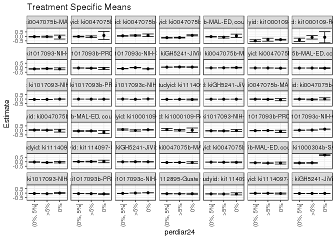

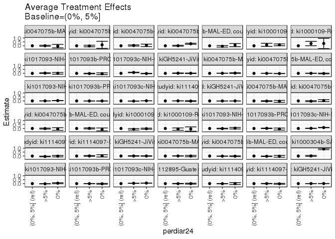

## Results Table

### Parameter: TSM

| agecat | studyid | country | intervention_level | baseline_level | estimate | ci_lower | ci_upper |
| --- | --- | --- | --- | --- | --- | --- | --- |
| 0-3 months | ki0047075b-MAL-ED | BANGLADESH | (0%, 5%] | NA | -0.0338626 | -0.0730833 | 0.0053581 |
| 0-3 months | ki0047075b-MAL-ED | BANGLADESH | >5% | NA | -0.0300587 | -0.0855574 | 0.0254400 |
| 0-3 months | ki0047075b-MAL-ED | BANGLADESH | 0% | NA | -0.0794143 | -0.2987633 | 0.1399348 |
| 0-3 months | ki0047075b-MAL-ED | INDIA | (0%, 5%] | NA | -0.0189903 | -0.0609969 | 0.0230162 |
| 0-3 months | ki0047075b-MAL-ED | INDIA | >5% | NA | -0.0425348 | -0.1361379 | 0.0510683 |
| 0-3 months | ki0047075b-MAL-ED | INDIA | 0% | NA | 0.1000734 | -0.3476191 | 0.5477659 |
| 0-3 months | ki0047075b-MAL-ED | NEPAL | (0%, 5%] | NA | 0.0613737 | 0.0167587 | 0.1059887 |
| 0-3 months | ki0047075b-MAL-ED | NEPAL | >5% | NA | 0.0976070 | 0.0400419 | 0.1551722 |
| 0-3 months | ki0047075b-MAL-ED | NEPAL | 0% | NA | 0.1163680 | -0.0342251 | 0.2669611 |
| 0-3 months | ki0047075b-MAL-ED | PERU | (0%, 5%] | NA | -0.1462259 | -0.1892022 | -0.1032496 |
| 0-3 months | ki0047075b-MAL-ED | PERU | >5% | NA | -0.1375471 | -0.1792558 | -0.0958384 |
| 0-3 months | ki0047075b-MAL-ED | PERU | 0% | NA | 0.1126237 | 0.0551011 | 0.1701464 |
| 0-3 months | ki0047075b-MAL-ED | TANZANIA, UNITED REPUBLIC OF | (0%, 5%] | NA | -0.0323152 | -0.0743650 | 0.0097345 |
| 0-3 months | ki0047075b-MAL-ED | TANZANIA, UNITED REPUBLIC OF | >5% | NA | -0.0993871 | -0.1887651 | -0.0100091 |
| 0-3 months | ki0047075b-MAL-ED | TANZANIA, UNITED REPUBLIC OF | 0% | NA | 0.0531462 | -0.1433157 | 0.2496082 |
| 0-3 months | ki1000109-EE | PAKISTAN | (0%, 5%] | NA | -0.4870258 | -0.5952550 | -0.3787966 |
| 0-3 months | ki1000109-EE | PAKISTAN | >5% | NA | -0.3696347 | -0.5367285 | -0.2025409 |
| 0-3 months | ki1000109-EE | PAKISTAN | 0% | NA | -0.3667728 | -0.4110092 | -0.3225363 |
| 0-3 months | ki1000109-ResPak | PAKISTAN | (0%, 5%] | NA | -0.3896507 | -0.5824027 | -0.1968987 |
| 0-3 months | ki1000109-ResPak | PAKISTAN | >5% | NA | -0.1071871 | -0.3019080 | 0.0875338 |
| 0-3 months | ki1000109-ResPak | PAKISTAN | 0% | NA | -0.0993461 | -0.7184068 | 0.5197146 |
| 0-3 months | ki1017093-NIH-Birth | BANGLADESH | (0%, 5%] | NA | -0.1295193 | -0.1622581 | -0.0967806 |
| 0-3 months | ki1017093-NIH-Birth | BANGLADESH | >5% | NA | -0.0990526 | -0.1417166 | -0.0563885 |
| 0-3 months | ki1017093-NIH-Birth | BANGLADESH | 0% | NA | -0.1250127 | -0.2315123 | -0.0185130 |
| 0-3 months | ki1017093b-PROVIDE | BANGLADESH | (0%, 5%] | NA | -0.0324772 | -0.0537057 | -0.0112487 |
| 0-3 months | ki1017093b-PROVIDE | BANGLADESH | >5% | NA | -0.0565326 | -0.0923010 | -0.0207643 |
| 0-3 months | ki1017093b-PROVIDE | BANGLADESH | 0% | NA | -0.0804829 | -0.1877391 | 0.0267732 |
| 0-3 months | ki1017093c-NIH-Crypto | BANGLADESH | (0%, 5%] | NA | -0.1004821 | -0.1224622 | -0.0785021 |
| 0-3 months | ki1017093c-NIH-Crypto | BANGLADESH | >5% | NA | 0.0078702 | -0.0165470 | 0.0322875 |
| 0-3 months | ki1017093c-NIH-Crypto | BANGLADESH | 0% | NA | -0.1245381 | -0.1420993 | -0.1069770 |

[output cut: 96 more lines]

### Parameter: E(Y)

| agecat | studyid | country | intervention_level | baseline_level | estimate | ci_lower | ci_upper |
| --- | --- | --- | --- | --- | --- | --- | --- |
| 0-3 months | ki0047075b-MAL-ED | BANGLADESH | NA | NA | -0.0339062 | -0.0659795 | -0.0018330 |
| 0-3 months | ki0047075b-MAL-ED | INDIA | NA | NA | -0.0204797 | -0.0596747 | 0.0187152 |
| 0-3 months | ki0047075b-MAL-ED | NEPAL | NA | NA | 0.0746202 | 0.0395269 | 0.1097135 |
| 0-3 months | ki0047075b-MAL-ED | PERU | NA | NA | -0.1581085 | -0.1906285 | -0.1255886 |
| 0-3 months | ki0047075b-MAL-ED | TANZANIA, UNITED REPUBLIC OF | NA | NA | -0.0461667 | -0.0847570 | -0.0075763 |
| 0-3 months | ki1000109-EE | PAKISTAN | NA | NA | -0.3938516 | -0.4364614 | -0.3512419 |
| 0-3 months | ki1000109-ResPak | PAKISTAN | NA | NA | -0.1934958 | -0.3384003 | -0.0485914 |
| 0-3 months | ki1017093-NIH-Birth | BANGLADESH | NA | NA | -0.1191165 | -0.1460676 | -0.0921654 |
| 0-3 months | ki1017093b-PROVIDE | BANGLADESH | NA | NA | -0.0413143 | -0.0594662 | -0.0231624 |
| 0-3 months | ki1017093c-NIH-Crypto | BANGLADESH | NA | NA | -0.1220821 | -0.1402761 | -0.1038881 |
| 0-3 months | kiGH5241-JiVitA-4 | BANGLADESH | NA | NA | 0.0673143 | 0.0523756 | 0.0822531 |
| 3-6 months | ki0047075b-MAL-ED | BANGLADESH | NA | NA | -0.0225211 | -0.0456381 | 0.0005960 |
| 3-6 months | ki0047075b-MAL-ED | NEPAL | NA | NA | -0.0214542 | -0.0480456 | 0.0051373 |
| 3-6 months | ki0047075b-MAL-ED | PERU | NA | NA | 0.0273803 | -0.0036374 | 0.0583980 |
| 3-6 months | ki0047075b-MAL-ED | TANZANIA, UNITED REPUBLIC OF | NA | NA | -0.0705448 | -0.1027245 | -0.0383652 |
| 3-6 months | ki1000109-EE | PAKISTAN | NA | NA | 0.0701161 | 0.0419135 | 0.0983187 |
| 3-6 months | ki1000109-ResPak | PAKISTAN | NA | NA | 0.0387792 | -0.0275800 | 0.1051384 |
| 3-6 months | ki1017093-NIH-Birth | BANGLADESH | NA | NA | -0.0509007 | -0.0730097 | -0.0287917 |
| 3-6 months | ki1017093b-PROVIDE | BANGLADESH | NA | NA | -0.0272428 | -0.0436954 | -0.0107902 |
| 3-6 months | ki1017093c-NIH-Crypto | BANGLADESH | NA | NA | 0.0267740 | 0.0099602 | 0.0435879 |
| 3-6 months | ki1114097-CMIN | PERU | NA | NA | -0.0576273 | -0.0800097 | -0.0352449 |
| 3-6 months | ki1114097-CONTENT | PERU | NA | NA | 0.0127563 | -0.0097402 | 0.0352528 |
| 3-6 months | kiGH5241-JiVitA-4 | BANGLADESH | NA | NA | -0.0090589 | -0.0227889 | 0.0046710 |
| 6-12 months | ki0047075b-MAL-ED | BANGLADESH | NA | NA | -0.0807393 | -0.0911050 | -0.0703737 |
| 6-12 months | ki0047075b-MAL-ED | NEPAL | NA | NA | -0.0488126 | -0.0594641 | -0.0381610 |
| 6-12 months | ki0047075b-MAL-ED | TANZANIA, UNITED REPUBLIC OF | NA | NA | -0.1240143 | -0.1396706 | -0.1083579 |
| 6-12 months | ki1000304b-SAS-FoodSuppl | INDIA | NA | NA | -0.1080113 | -0.1390238 | -0.0769988 |
| 6-12 months | ki1017093-NIH-Birth | BANGLADESH | NA | NA | -0.0530976 | -0.0624028 | -0.0437924 |
| 6-12 months | ki1017093b-PROVIDE | BANGLADESH | NA | NA | -0.0626151 | -0.0695574 | -0.0556729 |
| 6-12 months | ki1017093c-NIH-Crypto | BANGLADESH | NA | NA | -0.0315658 | -0.0388594 | -0.0242722 |
| 6-12 months | ki1112895-Guatemala BSC | GUATEMALA | NA | NA | -0.0751878 | -0.0881244 | -0.0622513 |
| 6-12 months | ki1114097-CMIN | PERU | NA | NA | -0.0944187 | -0.1050232 | -0.0838142 |
| 6-12 months | ki1114097-CONTENT | PERU | NA | NA | -0.0227186 | -0.0352036 | -0.0102335 |
| 6-12 months | kiGH5241-JiVitA-4 | BANGLADESH | NA | NA | -0.0383528 | -0.0427166 | -0.0339890 |
| 12-24 months | ki0047075b-MAL-ED | BANGLADESH | NA | NA | -0.0178490 | -0.0232486 | -0.0124494 |
| 12-24 months | ki0047075b-MAL-ED | NEPAL | NA | NA | -0.0295113 | -0.0345712 | -0.0244514 |
| 12-24 months | ki0047075b-MAL-ED | TANZANIA, UNITED REPUBLIC OF | NA | NA | -0.0393265 | -0.0471437 | -0.0315094 |
| 12-24 months | ki1017093-NIH-Birth | BANGLADESH | NA | NA | -0.0404278 | -0.0450901 | -0.0357656 |
| 12-24 months | ki1017093b-PROVIDE | BANGLADESH | NA | NA | -0.0081718 | -0.0120131 | -0.0043304 |
| 12-24 months | ki1017093c-NIH-Crypto | BANGLADESH | NA | NA | -0.0057326 | -0.0097260 | -0.0017391 |
| 12-24 months | ki1114097-CMIN | PERU | NA | NA | -0.0292246 | -0.0357414 | -0.0227079 |
| 12-24 months | kiGH5241-JiVitA-4 | BANGLADESH | NA | NA | -0.0146006 | -0.0164813 | -0.0127200 |

### Parameter: ATE

| agecat | studyid | country | intervention_level | baseline_level | estimate | ci_lower | ci_upper |
| --- | --- | --- | --- | --- | --- | --- | --- |
| 0-3 months | ki0047075b-MAL-ED | BANGLADESH | (0%, 5%] | (0%, 5%] | 0.0000000 | 0.0000000 | 0.0000000 |
| 0-3 months | ki0047075b-MAL-ED | BANGLADESH | >5% | (0%, 5%] | 0.0038039 | -0.0641547 | 0.0717625 |
| 0-3 months | ki0047075b-MAL-ED | BANGLADESH | 0% | (0%, 5%] | -0.0455517 | -0.2683795 | 0.1772762 |
| 0-3 months | ki0047075b-MAL-ED | INDIA | (0%, 5%] | (0%, 5%] | 0.0000000 | 0.0000000 | 0.0000000 |
| 0-3 months | ki0047075b-MAL-ED | INDIA | >5% | (0%, 5%] | -0.0235445 | -0.1261412 | 0.0790523 |
| 0-3 months | ki0047075b-MAL-ED | INDIA | 0% | (0%, 5%] | 0.1190637 | -0.3305952 | 0.5687226 |
| 0-3 months | ki0047075b-MAL-ED | NEPAL | (0%, 5%] | (0%, 5%] | 0.0000000 | 0.0000000 | 0.0000000 |
| 0-3 months | ki0047075b-MAL-ED | NEPAL | >5% | (0%, 5%] | 0.0362333 | -0.0366322 | 0.1090988 |
| 0-3 months | ki0047075b-MAL-ED | NEPAL | 0% | (0%, 5%] | 0.0549943 | -0.1012596 | 0.2112482 |
| 0-3 months | ki0047075b-MAL-ED | PERU | (0%, 5%] | (0%, 5%] | 0.0000000 | 0.0000000 | 0.0000000 |
| 0-3 months | ki0047075b-MAL-ED | PERU | >5% | (0%, 5%] | 0.0086788 | -0.0480048 | 0.0653624 |
| 0-3 months | ki0047075b-MAL-ED | PERU | 0% | (0%, 5%] | 0.2588496 | 0.1883088 | 0.3293905 |
| 0-3 months | ki0047075b-MAL-ED | TANZANIA, UNITED REPUBLIC OF | (0%, 5%] | (0%, 5%] | 0.0000000 | 0.0000000 | 0.0000000 |
| 0-3 months | ki0047075b-MAL-ED | TANZANIA, UNITED REPUBLIC OF | >5% | (0%, 5%] | -0.0670719 | -0.1654649 | 0.0313212 |
| 0-3 months | ki0047075b-MAL-ED | TANZANIA, UNITED REPUBLIC OF | 0% | (0%, 5%] | 0.0854614 | -0.1154586 | 0.2863815 |
| 0-3 months | ki1000109-EE | PAKISTAN | (0%, 5%] | (0%, 5%] | 0.0000000 | 0.0000000 | 0.0000000 |
| 0-3 months | ki1000109-EE | PAKISTAN | >5% | (0%, 5%] | 0.1173911 | -0.0805173 | 0.3152995 |
| 0-3 months | ki1000109-EE | PAKISTAN | 0% | (0%, 5%] | 0.1202530 | 0.0048133 | 0.2356928 |
| 0-3 months | ki1000109-ResPak | PAKISTAN | (0%, 5%] | (0%, 5%] | 0.0000000 | 0.0000000 | 0.0000000 |
| 0-3 months | ki1000109-ResPak | PAKISTAN | >5% | (0%, 5%] | 0.2824636 | 0.0084754 | 0.5564518 |
| 0-3 months | ki1000109-ResPak | PAKISTAN | 0% | (0%, 5%] | 0.2903046 | -0.3580699 | 0.9386791 |
| 0-3 months | ki1017093-NIH-Birth | BANGLADESH | (0%, 5%] | (0%, 5%] | 0.0000000 | 0.0000000 | 0.0000000 |
| 0-3 months | ki1017093-NIH-Birth | BANGLADESH | >5% | (0%, 5%] | 0.0304668 | -0.0205812 | 0.0815147 |
| 0-3 months | ki1017093-NIH-Birth | BANGLADESH | 0% | (0%, 5%] | 0.0045067 | -0.1061348 | 0.1151482 |
| 0-3 months | ki1017093b-PROVIDE | BANGLADESH | (0%, 5%] | (0%, 5%] | 0.0000000 | 0.0000000 | 0.0000000 |
| 0-3 months | ki1017093b-PROVIDE | BANGLADESH | >5% | (0%, 5%] | -0.0240554 | -0.0656461 | 0.0175353 |
| 0-3 months | ki1017093b-PROVIDE | BANGLADESH | 0% | (0%, 5%] | -0.0480057 | -0.1573420 | 0.0613305 |
| 0-3 months | ki1017093c-NIH-Crypto | BANGLADESH | (0%, 5%] | (0%, 5%] | 0.0000000 | 0.0000000 | 0.0000000 |
| 0-3 months | ki1017093c-NIH-Crypto | BANGLADESH | >5% | (0%, 5%] | 0.1083523 | 0.0749561 | 0.1417486 |
| 0-3 months | ki1017093c-NIH-Crypto | BANGLADESH | 0% | (0%, 5%] | -0.0240560 | -0.0520519 | 0.0039399 |

[output cut: 96 more lines]